# Classroom Notes

Reginald Carey

April 6, 2015

The proboability that nothing occurs is 0

The probability that something occurs is 1

The probability of something is 1 minus the probability that the opposite occurs

The probability of at least one of two (or more) things that can not simultaneously occur (mutulally exclusive) is the sum of their respective probabilities

If an event A implies the occurrence of event B, then the probability of A occurring is less than the probability that B occurs

For any two events the probability that at least one occurs is the sum of their probabilities minus their intersection

$P(A \cup B) = P(A) + P(B) - P(A \cap B)$

Discrete Random Variables

Continuous Random Variables

### Probability Mass Functions (PMF)

A probability mass function evaulated at a value corresponds to the probability that a random variable takes tat value. To be a vaid pmf a function, p, must satisfy

1. It must always be larger than or equal to 0.
2. The sum of the possible values that the random variable can take has to add up to one.

X = 0 represents tails and X = 1 represents heads.

$p(x) = (\rfrac{1}{2})^{2}(\rfrac{1}{2})^{1-x} \text{ for } x=0,1$

That was for a fair coin flip. For an unfair coin flip we have

$p(x) = (\theta)^{x}(1-\theta)^{1-x}\text{ for }x=0,1$

### Probability Density Function (PDF)

A probability density function (pdf), is a function associated with a continuous random variable

To be a valid pdf, a function must satisfy

1. It must be larger than or equal to zero everywhere
2. The total area under it must be one.

Areas under probabilities correspond to probabilities for that random variable.

#### Example

$f(x) = \left\{ \begin{array}{1 1} 2x & \quad \text{ for } & \quad 0<x<1\\ 0 & \quad \text{ otherwise } \end{array} \right.$

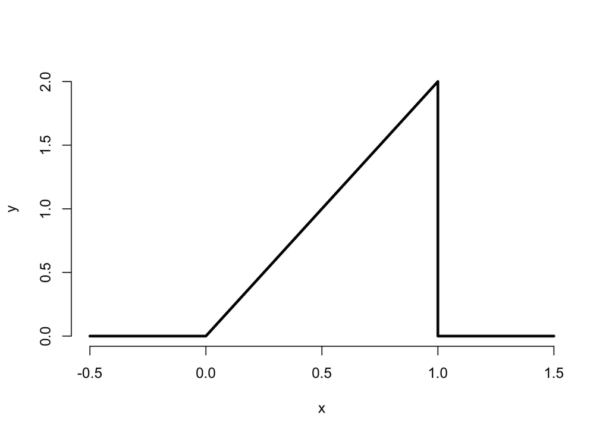

```r
x <- c(-0.5, 0, 1, 1, 1.5)
y <- c(0, 0, 2, 0, 0)
plot(x,y,lwd=3,frame=FALSE,type="l")
```

```r
1.5 * 0.75/2
```

```
## [1] 0.5625
```

Beta Distribution

```r
pbeta(0.75, 2, 1)
```

```
## [1] 0.5625
```

### Cumulative Distribution Function and Survival Function

CDF (cumulative distribution function) of a random variable, $X$, returns the probability that the random variable is less than or equal to the value $x$.

$F(x) = P(X \leq x)$

The *survival function* of a random variable $X$ is defined as the probability that the random varialbe is greater than the value $x$

$S(x) = P(X > x)$

Note that this is 1-CDF

### Quantiles

The $\alpha^{th}$ *quantile* of a distribution with distribution function $F$ is the point $x_{\alpha}$ so that

$F(x_{\alpha}) = \alpha$

R can approximate quantiles for you for common distributions

```r
qbeta(0.5, 2, 1)
```

```
## [1] 0.7071068
```

## CONDITIONAL PROBABILITY

### Conditional probability, definition

- Let $B$ be an event so that $P(B) > 0$

$P(A|B) = \frac {P(A \cap B)} {P(B)}$

If they are independent then

$P(A|B) = \frac {P(A)P(B)} {P(B)} = P(A)$

Example : Die rolls

$A = \{1\}, B = \{1,3,5\}$

$P(\text{one given that roll is odd}) = P(A|B)$ $=\frac {P(A \cap B)} {P(B)}$ $=\frac {P(A)} {P(B)}$

$=\frac {1/6} {3/6} = \frac {1} {3}$

## BAYES’ RULE

$P(B|A) = \frac {P(A|B)P(B)} {P(A|B)P(B) + P(A|B^{c})P(B^{c})}$

### Diagnostic tests

Let $+$ and $-$ be the events that the result of a diagnostic test is positive or negative respectively

Let $D$ and $D^{c}$ be the event that the subject of the test has or does not have the disease respectively

$\text{ Sensitivity } = P(+|D)$ $\text{ Specificity } = P(-|D^{c})$

#### More definitions

Positive predictive value $= P(D|+)$

Negative predictive value $= P(D^{c}|-)$

Prevalence of disease $= P(D)$

### Example

sensitivity of 99.7%

specificity of 98.5%

population with a 0.1% prevalence of HIV

Looking for $P(D|+)$

$P(D|+) = \frac {P(+|D)P(D)} {P(+|D)P(D)+P(+|D^{c})P(D^{c})}$

$= \frac {P(+|D)P(D)} {P(+|D)P(D) + \{ 1 - P(-|D^{c})\}\{1-P(D^{c})\}}$

$= \frac {.997 \times .001} {.997 \times .001 + .015 \times .999}$

$= .062$

# REVIEW 03 02 BAYE’S RULE VIDEO LECTURE - VERY IMPORTANT TO “GET IT”